# Hmisc Examples

FE Harrell

2016-08-16

# Introduction

This is a set of reproducible examples put together in an `rmarkdown` notebook using `RStudio` and `knitr`. When viewing the resulting [html file](http://data.vanderbilt.edu/fh/R/Hmisc/examples.nb.html) you can see all the code, and can download the entire `rmarkdown` script, which is especially helpful for seeing how `knitr` chunks are specified. Graphics that have a [plotly](http://plot.ly/r) method for them are rendered using `plotly` instead of using defaults such as base graphics, `lattice`, or `ggplot2`. That way the plots are somewhat interactive, e.g., allow for drill-down for more information without the viewer needing to install `R`.

Much of the tabular output produced here was created using `html` methods, which are especially easy to implement with `rmarkdown` and make for output that can be directly opened using word processors.

Static graphics are in `png` format.

# Setup

```r
require(Hmisc)
```

```r
knitrSet(lang='markdown', h=5.5, w=7)
options(grType='plotly') # for certain graphics functions
mu <- markupSpecs$html   # markupSpecs is in Hmisc
subtext <- mu$subtext
code    <- mu$code
```

The following hidden command (`r mu$widescreen()`), causes the html notebook to use an entire wide screen.

# Fetching Data, Modifying Variables, and Printing Data Dictionary

The `getHdata` function is used to fetch a dataset from the Vanderbilt `DataSets` web site. `upData` is used to

- create a new variable from an old one
- add labels to 2 variables
- add units to the new variable
- remove the old variable
- automatically move units of measurements from parenthetical expressions in labels to separate `units` attributed used by `Hmisc` and `rms` functions for table making and graphics

`contents` is used to print a data dictionary, run through an `html` method for nicer output.

```r
getHdata(pbc)
# Have upData move units from labels to separate attribute
pbc <- upData(pbc,
              fu.yrs = fu.days / 365.25,
              labels = c(fu.yrs = 'Follow-up Time',
                         status = 'Death or Liver Transplantation'),
              units = c(fu.yrs = 'year'),
              drop  = 'fu.days',
              moveUnits=TRUE, html=TRUE)
```

```
Input object size:   76592 bytes;    19 variables    418 observations
 Label for bili changed from Serum Bilirubin (mg/dl) to Serum Bilirubin
    units set to mg/dl
 Label for albumin changed from Albumin (gm/dl) to Albumin
    units set to gm/dl
 Label for protime changed from Prothrombin Time (sec.) to Prothrombin Time
    units set to sec.
 Label for alk.phos changed from Alkaline Phosphatase (U/liter) to Alkaline Phosphatase
    units set to U/liter
 Label for sgot changed from SGOT (U/ml) to SGOT
    units set to U/ml
 Label for chol changed from Cholesterol (mg/dl) to Cholesterol
    units set to mg/dl
 Label for trig changed from Triglycerides (mg/dl) to Triglycerides
    units set to mg/dl
 Label for platelet changed from Platelets (per cm^3/1000) to Platelets
    units set to per cm^3/1000
 Label for copper changed from Urine Copper (ug/day) to Urine Copper
    units set to ug/day
 Added variable     fu.yrs
 Dropped variable   fu.days
 New object size:   80224 bytes;    19 variables    418 observations
```

```r
h <- html(contents(pbc), file='', maxlevels=10, levelType='table')
```

#### Data frame:pbc

418 observations and 19 variables, maximum # NAs:136

| Name | Labels | Units | Levels | Storage | NAs |
| --- | --- | --- | --- | --- | --- |
| bili | Serum Bilirubin | mg/dl |  | double | 0 |
| albumin | Albumin | gm/dl |  | double | 0 |
| stage | Histologic Stage, Ludwig Criteria |  |  | integer | 6 |
| protime | Prothrombin Time | sec. |  | double | 2 |
| sex |  |  | 2 | integer | 0 |
| age | Age |  |  | double | 0 |
| spiders |  |  | 2 | integer | 106 |
| hepatom |  |  | 2 | integer | 106 |
| ascites |  |  | 2 | integer | 106 |
| alk.phos | Alkaline Phosphatase | U/liter |  | double | 106 |
| sgot | SGOT | U/ml |  | double | 106 |
| chol | Cholesterol | mg/dl |  | integer | 134 |
| trig | Triglycerides | mg/dl |  | integer | 136 |
| platelet | Platelets | per cm^3/1000 |  | integer | 110 |
| drug |  |  | 3 | integer | 0 |
| status | Death or Liver Transplantation |  |  | integer | 0 |
| edema |  |  | 3 | integer | 0 |
| copper | Urine Copper | ug/day |  | integer | 108 |
| fu.yrs | Follow-up Time | year |  | double | 0 |

[output not shown]

# Descriptive Statistics Without Stratification

The html method is used for the `describe` function, and the output is put in a scrollable box. Other than for the overall title and variable names and labels, the output size used here is 80 (0.8 × the usual font size[^1]). But the graphical display of the descriptives statistics that follows this is probably better.

```r
d <- describe(pbc)
html(d, size=80, scroll=TRUE)
```

pbc  
19 Variables 418 Observations

**bili**: Serum Bilirubin `mg/dl`

| n | missing | unique | Info | Mean | .05 | .10 | .25 | .50 | .75 | .90 | .95 |
| --- | --- | --- | --- | --- | --- | --- | --- | --- | --- | --- | --- |
| 418 | 0 | 98 | 0.998 | 3.221 | 0.50 | 0.60 | 0.80 | 1.40 | 3.40 | 8.03 | 14.00 |

| lowest : | 0.3 | 0.4 | 0.5 | 0.6 | 0.7 |
| --- | --- | --- | --- | --- | --- |
| highest: | 21.6 | 22.5 | 24.5 | 25.5 | 28.0 |

**albumin**: Albumin `gm/dl`

| n | missing | unique | Info | Mean | .05 | .10 | .25 | .50 | .75 | .90 | .95 |
| --- | --- | --- | --- | --- | --- | --- | --- | --- | --- | --- | --- |
| 418 | 0 | 154 | 1 | 3.497 | 2.750 | 2.967 | 3.243 | 3.530 | 3.770 | 4.010 | 4.141 |

| lowest : | 1.96 | 2.10 | 2.23 | 2.27 | 2.31 |
| --- | --- | --- | --- | --- | --- |
| highest: | 4.30 | 4.38 | 4.40 | 4.52 | 4.64 |

**stage**: Histologic Stage, Ludwig Criteria

| n | missing | unique | Info | Mean |
| --- | --- | --- | --- | --- |
| 412 | 6 | 4 | 0.893 | 3.024 |

1 (21, 0.051), 2 (92, 0.223), 3 (155, 0.376), 4 (144, 0.350)

**protime**: Prothrombin Time `sec.`

| n | missing | unique | Info | Mean | .05 | .10 | .25 | .50 | .75 | .90 | .95 |
| --- | --- | --- | --- | --- | --- | --- | --- | --- | --- | --- | --- |
| 416 | 2 | 48 | 0.998 | 10.73 | 9.60 | 9.80 | 10.00 | 10.60 | 11.10 | 12.00 | 12.45 |

| lowest : | 9.0 | 9.1 | 9.2 | 9.3 | 9.4 |
| --- | --- | --- | --- | --- | --- |
| highest: | 13.8 | 14.1 | 15.2 | 17.1 | 18.0 |

**sex**

| n | missing | unique |
| --- | --- | --- |
| 418 | 0 | 2 |

male (44, 0.105), female (374, 0.895)

**age**: Age

| n | missing | unique | Info | Mean | .05 | .10 | .25 | .50 | .75 | .90 | .95 |
| --- | --- | --- | --- | --- | --- | --- | --- | --- | --- | --- | --- |
| 418 | 0 | 345 | 1 | 50.74 | 33.84 | 36.37 | 42.83 | 51.00 | 58.24 | 64.30 | 67.92 |

| lowest : | 26.27789 | 28.88433 | 29.55510 | 30.27515 | 30.57358 |
| --- | --- | --- | --- | --- | --- |
| highest: | 74.52430 | 75.00000 | 75.01164 | 76.70910 | 78.43943 |

**spiders**

| n | missing | unique |
| --- | --- | --- |
| 312 | 106 | 2 |

absent (222, 0.712), present (90, 0.288)

**hepatom**

| n | missing | unique |
| --- | --- | --- |
| 312 | 106 | 2 |

absent (152, 0.487), present (160, 0.513)

**ascites**

| n | missing | unique |
| --- | --- | --- |
| 312 | 106 | 2 |

absent (288, 0.923), present (24, 0.077)

**alk.phos**: Alkaline Phosphatase `U/liter`

| n | missing | unique | Info | Mean | .05 | .10 | .25 | .50 | .75 | .90 | .95 |
| --- | --- | --- | --- | --- | --- | --- | --- | --- | --- | --- | --- |
| 312 | 106 | 295 | 1 | 1983 | 599.6 | 663.0 | 871.5 | 1259.0 | 1980.0 | 3826.4 | 6669.9 |

| lowest : | 289.0 | 310.0 | 369.0 | 377.0 | 414.0 |
| --- | --- | --- | --- | --- | --- |
| highest: | 11046.6 | 11320.2 | 11552.0 | 12258.8 | 13862.4 |

**sgot**: SGOT `U/ml`

| n | missing | unique | Info | Mean | .05 | .10 | .25 | .50 | .75 | .90 | .95 |
| --- | --- | --- | --- | --- | --- | --- | --- | --- | --- | --- | --- |
| 312 | 106 | 179 | 1 | 122.6 | 54.25 | 60.45 | 80.60 | 114.70 | 151.90 | 196.47 | 219.25 |

| lowest : | 26.35 | 28.38 | 41.85 | 43.40 | 45.00 |
| --- | --- | --- | --- | --- | --- |
| highest: | 288.00 | 299.15 | 328.60 | 338.00 | 457.25 |

**chol**: Cholesterol `mg/dl`

| n | missing | unique | Info | Mean | .05 | .10 | .25 | .50 | .75 | .90 | .95 |
| --- | --- | --- | --- | --- | --- | --- | --- | --- | --- | --- | --- |
| 284 | 134 | 201 | 1 | 369.5 | 188.4 | 213.6 | 249.5 | 309.5 | 400.0 | 560.8 | 674.0 |

| lowest : | 120 | 127 | 132 | 149 | 151 |
| --- | --- | --- | --- | --- | --- |
| highest: | 1336 | 1480 | 1600 | 1712 | 1775 |

**trig**: Triglycerides `mg/dl`

| n | missing | unique | Info | Mean | .05 | .10 | .25 | .50 | .75 | .90 | .95 |
| --- | --- | --- | --- | --- | --- | --- | --- | --- | --- | --- | --- |
| 282 | 136 | 146 | 1 | 124.7 | 56.00 | 63.10 | 84.25 | 108.00 | 151.00 | 195.00 | 230.95 |

| lowest : | 33 | 44 | 46 | 49 | 50 |
| --- | --- | --- | --- | --- | --- |
| highest: | 319 | 322 | 382 | 432 | 598 |

**platelet**: Platelets `per cm3/1000`

| n | missing | unique | Info | Mean | .05 | .10 | .25 | .50 | .75 | .90 | .95 |
| --- | --- | --- | --- | --- | --- | --- | --- | --- | --- | --- | --- |
| 308 | 110 | 210 | 1 | 261.9 | 117.7 | 139.7 | 199.8 | 257.0 | 322.5 | 386.5 | 430.6 |

| lowest : | 62 | 70 | 71 | 79 | 80 |
| --- | --- | --- | --- | --- | --- |
| highest: | 493 | 514 | 518 | 539 | 563 |

**drug**

| n | missing | unique |
| --- | --- | --- |
| 418 | 0 | 3 |

D-penicillamine (154, 0.368), placebo (158, 0.378), not randomized (106, 0.254)

**status**: Death or Liver Transplantation

| n | missing | unique | Info | Sum | Mean |
| --- | --- | --- | --- | --- | --- |
| 418 | 0 | 2 | 0.71 | 161 | 0.3852 |

**edema**

| n | missing | unique |
| --- | --- | --- |
| 418 | 0 | 3 |

no edema (354, 0.847), edema, no diuretic therapy (44, 0.105), edema despite diuretic therapy (20, 0.048)

**copper**: Urine Copper `ug/day`

| n | missing | unique | Info | Mean | .05 | .10 | .25 | .50 | .75 | .90 | .95 |
| --- | --- | --- | --- | --- | --- | --- | --- | --- | --- | --- | --- |
| 310 | 108 | 158 | 1 | 97.65 | 17.45 | 24.00 | 41.25 | 73.00 | 123.00 | 208.10 | 249.20 |

| lowest : | 4 | 9 | 10 | 11 | 12 |
| --- | --- | --- | --- | --- | --- |
| highest: | 412 | 444 | 464 | 558 | 588 |

**fu.yrs**: Follow-up Time `year`

| n | missing | unique | Info | Mean | .05 | .10 | .25 | .50 | .75 | .90 | .95 |
| --- | --- | --- | --- | --- | --- | --- | --- | --- | --- | --- | --- |
| 418 | 0 | 399 | 1 | 5.251 | 0.671 | 1.661 | 2.992 | 4.736 | 7.155 | 9.649 | 11.063 |

| lowest : | 0.1122519 | 0.1177276 | 0.1396304 | 0.1943874 | 0.2108145 |
| --- | --- | --- | --- | --- | --- |
| highest: | 12.3203285 | 12.3449692 | 12.3832991 | 12.4736482 | 13.1279945 |

```r
plot(d)
```

[interactive chart not shown]

[interactive chart not shown]

```
NA
```

# Stratified Descriptive Statistics

Produce stratified quantiles, means/SD, and proportions by treatment group. Plot the results before rendering as an advanced html table:

- categorical variables: a single dot chart
- continuous variables: a series of extended box plots

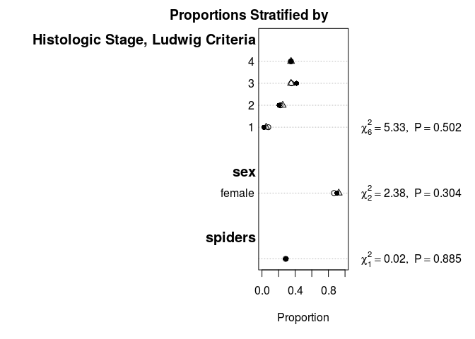

```r
s <- summaryM(bili + albumin + stage + protime + sex + age + spiders +
              alk.phos + sgot + chol ~ drug, data=pbc,
                            overall=FALSE, test=TRUE)
plot(s, which='categorical')
```

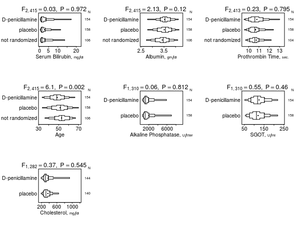

```r
plot(s, which='continuous')
```

```r
html(s, caption='Baseline characteristics by randomized treatment',
     exclude1=TRUE, npct='both', digits=3,
     prmsd=TRUE, brmsd=TRUE, msdsize=mu$smaller2)
```

| Baseline characteristics by randomized treatment. | Baseline characteristics by randomized treatment. N | Baseline characteristics by randomized treatment. D-penicillamine *N=154* | Baseline characteristics by randomized treatment. placebo *N=158* | Baseline characteristics by randomized treatment. not randomized *N=106* | Baseline characteristics by randomized treatment. Test Statistic |
| --- | --- | --- | --- | --- | --- |
| Serum Bilirubin `mg/dl` | 418 | 0.725 1.300 3.600 3.649 ± 5.282 | 0.800 1.400 3.200 2.873 ± 3.629 | 0.725 1.400 3.075 3.117 ± 4.043 | *F*<sub>2, 415</sub>=0.03, P=0.972<sup>1</sup> |
| Albumin `gm/dl` | 418 | 3.342 3.545 3.777 3.524 ± 0.396 | 3.212 3.565 3.830 3.516 ± 0.443 | 3.125 3.470 3.720 3.431 ± 0.435 | *F*<sub>2, 415</sub>=2.13, P=0.12<sup>1</sup> |
| Histologic Stage, Ludwig Criteria : 1 | 412 | 0.03 <sup>4</sup>⁄<sub>154</sub> | 0.08 <sup>12</sup>⁄<sub>158</sub> | 0.05 <sup>5</sup>⁄<sub>100</sub> | χ<sup>2</sup><sub>6</sub>=5.33, P=0.502<sup>2</sup> |
| 2 |  | 0.21 <sup>32</sup>⁄<sub>154</sub> | 0.22 <sup>35</sup>⁄<sub>158</sub> | 0.25 <sup>25</sup>⁄<sub>100</sub> |  |
| 3 |  | 0.42 <sup>64</sup>⁄<sub>154</sub> | 0.35 <sup>56</sup>⁄<sub>158</sub> | 0.35 <sup>35</sup>⁄<sub>100</sub> |  |
| 4 |  | 0.35 <sup>54</sup>⁄<sub>154</sub> | 0.35 <sup>55</sup>⁄<sub>158</sub> | 0.35 <sup>35</sup>⁄<sub>100</sub> |  |
| Prothrombin Time `sec.` | 416 | 10.000 10.600 11.400 10.800 ± 1.138 | 10.025 10.600 11.000 10.653 ± 0.851 | 10.100 10.600 11.000 10.750 ± 1.078 | *F*<sub>2, 413</sub>=0.23, P=0.795<sup>1</sup> |
| sex : female | 418 | 0.90 <sup>139</sup>⁄<sub>154</sub> | 0.87 <sup>137</sup>⁄<sub>158</sub> | 0.92 <sup>98</sup>⁄<sub>106</sub> | χ<sup>2</sup><sub>2</sub>=2.38, P=0.304<sup>2</sup> |
| Age | 418 | 41.43 48.11 55.80 48.58 ± 9.96 | 42.98 51.93 58.90 51.42 ± 11.01 | 46.00 53.00 61.00 52.87 ± 9.78 | *F*<sub>2, 415</sub>=6.1, P=0.002<sup>1</sup> |
| spiders | 312 | 0.29 <sup>45</sup>⁄<sub>154</sub> | 0.28 <sup>45</sup>⁄<sub>158</sub> |  | χ<sup>2</sup><sub>1</sub>=0.02, P=0.885<sup>2</sup> |
| Alkaline Phosphatase `U/liter` | 312 | 922 1283 1950 1943 ± 2102 | 841 1214 2028 2021 ± 2183 |  | *F*<sub>1, 310</sub>=0.06, P=0.812<sup>3</sup> |
| SGOT `U/ml` | 312 | 83.8 117.4 151.9 125.0 ± 58.9 | 76.7 111.6 151.5 120.2 ± 54.5 |  | *F*<sub>1, 310</sub>=0.55, P=0.46<sup>3</sup> |
| Cholesterol `mg/dl` | 284 | 254 304 377 374 ± 252 | 248 316 417 365 ± 210 |  | *F*<sub>1, 282</sub>=0.37, P=0.545<sup>3</sup> |

*a* *b* *c* represent the lower quartile *a*, the median *b*, and the upper quartile *c* for continuous variables. *x± s* represents X ± 1 SD. *N* is the number of non-missing values. Tests used: <sup>1</sup>Kruskal-Wallis test; <sup>2</sup>Pearson test; <sup>3</sup>Wilcoxon test .

To cite R in publication use:

R Core Team (2016). *R: A Language and Environment for Statistical Computing*. R Foundation for Statistical Computing, Vienna, Austria. https://www.R-project.org/.

[^1]: The default is 75% size.
[^2]: `mu` is a copy of the part of the `Hmisc` package object `markupSpecs` that is for html. It includes a function `session` that renders the session environment (including package versions) in html.